# 데이터 과학: 재현가능한 저작

영문 이력서: 데이터프레임 → PDF

xwMOOC

2019-07-26

# 1 이력서 PDF 데이터 [^1]

[`vitae`](https://github.com/ropenscilabs/vitae) 팩키지를 설치하고 앞서 추출한 데이터프레임을 바탕으로 이력서 PDF 파일을 제작한다. 먼저 앞서 PDF 이력서에서 추출한 정형 데이터를 확인한다. PDF 이력서에서 텍스트를 추출하여 정형데이터로 제작하는 것은 데이터 과학: 재현가능한 저작 영문 이력서: DF → PDF → DF 웹사이트를 참고한다.

```r
library(tidyverse)

resume_df <- readRDS("data/resume_df.rds")
resume_df
```

```
# A tibble: 1 x 9
  인적사항   요약    직장    수상    발표    저서    심사    학교    특활
  <list>     <list>  <list>  <list>  <list>  <list>  <list>  <list>  <list>
1 <tibble [~ <tibbl~ <tibbl~ <tibbl~ <tibbl~ <tibbl~ <tibbl~ <tibbl~ <tibb~
```

# 2 이력서 제작

[`vitae`](https://github.com/ropenscilabs/vitae) 팩키지를 설치하면 이력서 제작 템플릿이 자동으로 설치된다. 이를 바탕으로 이력서를 제작하려면 `File` → `New File` → `R Markdown` 을 선택하고 **Curriculum Vitae (Awesome-CV format)** 을 선택한다.

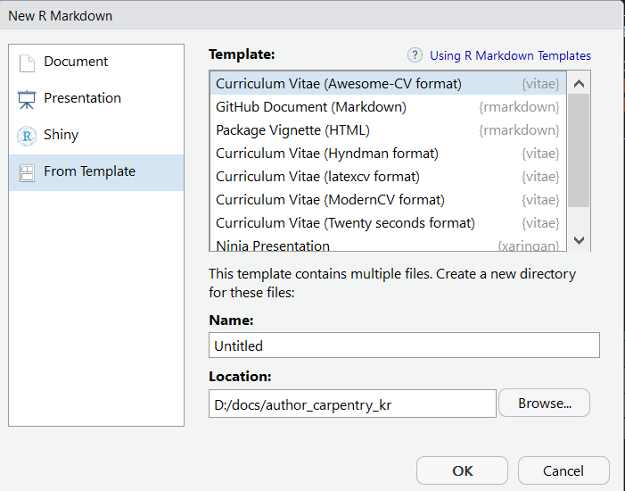

R마크다운 YAML 헤더에 기본 인적사항을 기술한다.

```r
---
name: Byungjin
surname: Park
position: "Software Architect, Security Expert"
address: "42-8, Bangbae-ro 15-gil, Seocho-gu, Seoul, 00681, Rep. of KOREA"
phone: (+82) 10-9030-1843
www: www.posquit0.com
email: "posquit0.bj@gmail.com"
twitter: posquit0
github: posquit0
linkedin: posquit0
date: "`r format(Sys.time(), '%B %Y')`"
output: vitae::awesomecv
editor_options:
  chunk_output_type: console
---
```

이력서에 크게 자유기술하는 경우와 데이터프레임에서 칼럼을 뽑아내서 이를 $\LaTeX$에 넘기는 두가지 경우로 나눠 이력서를 작성한다.

**텍스트 기술**

```r
resume_df %>%
  select(요약) %>%
  unnest() %>%
  brief_entries(요약)
```

**데이터프레임**

```r
resume_df %>%
  select(직장) %>%
  unnest() %>%
  detailed_entries(with=직장명, where=근무지, what=역할, when=근무연도)
```

## 2.1 이력서 제작 코드

이력서 제작 전체 R마크다운 파일은 이력서 파일을 다운로드 받아볼 수 있다.

````r
# ---
# name: Byungjin
# surname: Park
# position: "Software Architect, Security Expert"
# address: "42-8, Bangbae-ro 15-gil, Seocho-gu, Seoul, 00681, Rep. of KOREA"
# phone: (+82) 10-9030-1843
# www: www.posquit0.com
# email: "posquit0.bj@gmail.com"
# twitter: posquit0
# github: posquit0
# linkedin: posquit0
# date: "`r format(Sys.time(), '%B %Y')`"
# output: vitae::awesomecv
# editor_options:
#   chunk_output_type: console
# ---
#
# ```{r setup, include=FALSE}
# knitr::opts_chunk$set(echo = FALSE, warning = FALSE, message = FALSE)
# library(vitae)
# library(tidyverse)
# resume_df <- readRDS("../data/resume_df.rds")
# ```
#
# # Summary
#
# ```{r resume-summary}
# resume_df %>%
#   select(요약) %>%
#   unnest() %>%
#   brief_entries(요약)
# ```
#
# # Work Experience
#
# ```{r vitae-work}
# resume_df %>%
#   select(직장) %>%
#   unnest() %>%
#   detailed_entries(with=직장명, where=근무지, what=역할, when=근무연도)
# ```
#
# <!-- # Honors & Awards -->
#
# <!-- ```{r vitae-honors} -->
# <!-- resume_df %>%  -->
# <!--   select(수상) %>%  -->
# <!--   unnest() %>%  -->
# <!--   detailed_entries(when=수상년도, 수상등수, 수상프로그램, 수상지역) -->
# <!-- ``` -->
#
# # Presentation
#
# ```{r vitae-presentation}
# resume_df %>%
#   select(발표) %>%
#   unnest() %>%
#   detailed_entries(발표제목, 발표일)
# ```
#
# # Writing
#
# ```{r vitae-writing}
# resume_df %>%
#   select(저서) %>%
#   unnest() %>%
#   detailed_entries(저서명, what=저자명, when=저작연도)
# ```
#
#
# # Education
#
# ```{r vitae-education}
# resume_df %>%
#   select(학교) %>%
#   unnest() %>%
#   detailed_entries(학교명, 학교위치)
# ```
#
# # Extracurricular Activity
#
# ```{r extra-curricular}
# resume_df %>%
#   select(특활) %>%
#   unnest() %>%
#   detailed_entries(with=특활명, where=특활지역, what=특활역할, when=특활기간)
# ```
#
````

# 3 제작한 이력서

**첫번째 페이지**

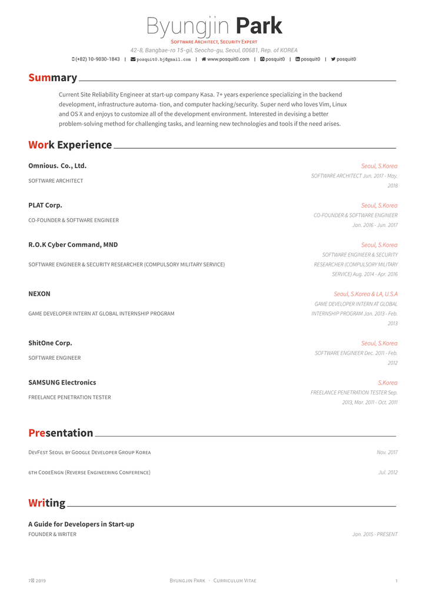

```r
library(pdftools)
library(magick)

resume_first_png <- pdf_render_page("resume/resume.pdf", page = 1, dpi = 300, numeric = FALSE)
image_read(resume_first_png)
```

**두번째 페이지**

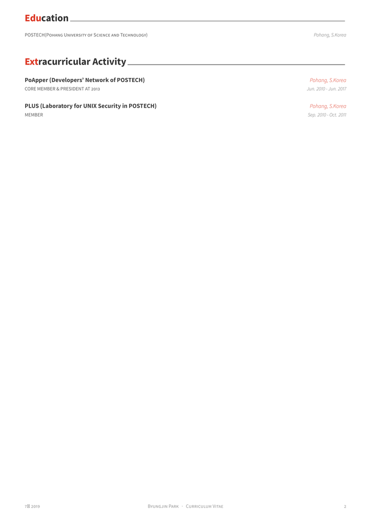

```r
resume_second_png <- pdf_render_page("resume/resume.pdf", page = 2, dpi = 300, numeric = FALSE)
image_read(resume_second_png)
```

[^1]: [데이터 사이언스: 저작(Authoring), “이력서(Resume)”](https://statkclee.github.io/ds-authoring/ds-resume.html)